# Turn up the Heat! A Tutorial for the MAGMA R-package.

### Balance Evaluation

After balance estimation, the “optimal” sample size to extract remains veiled. Which sample size is “optimal” strongly depends on the specific research aim. For example, the sample size requirements of some statistical procedures may narrow the selection, as may the need to eliminate a specific pairwise effect. We therefore encourage to adapt the selection of optimal sample size to the specific research aim.

A first indicator of such an optimal sample size is the trend of the balance criteria across the iteratively increased sample size. The function `Plot_MAGMA` visualizes this trend. The one mandatory argument, `Balance`, specifies the object of the balance estimation results. Note that this object must be the result of a `Balance_MAGMA` function. Per default, `Plot_MAGMA` creates plots for all four balance criteria. However, the `criterion` argument enables the plotting of specific balance criteria. Note that running this code will result in a warning. This warning is a result of the specified minimum sample size for balance estimation and can be ignored.

The trend of these plots depends strongly on the data. Nonetheless, they can be a good indicator of breakpoints in the sample size-balance associations. `Plot_MAGMA` uses fixed limits for the y-axis. This ensures comparability of these plots and prevents misinterpretation due to a restricted y-axis range. Both *d*-ratio and adjusted *d*-ratio vary between 0 and 1. Although Pillai’s Trace has theoretically the same range, we set the limits to 0 and 0.5. Larger values are unlikely and indicate a poor balance. A stricter limit might restrict a comprehensive trend evaluation. For mean *g* we set the limits to 0 and 1. The lower limit 0 corresponds to the theoretical lower limit. The rationale for the upper limit is comparable to that of Pillai’s Trace.

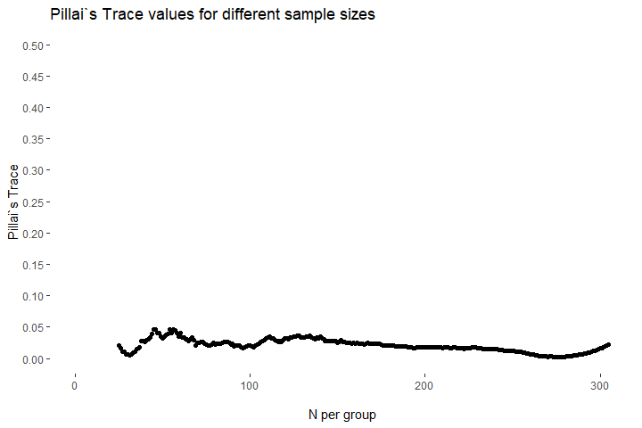

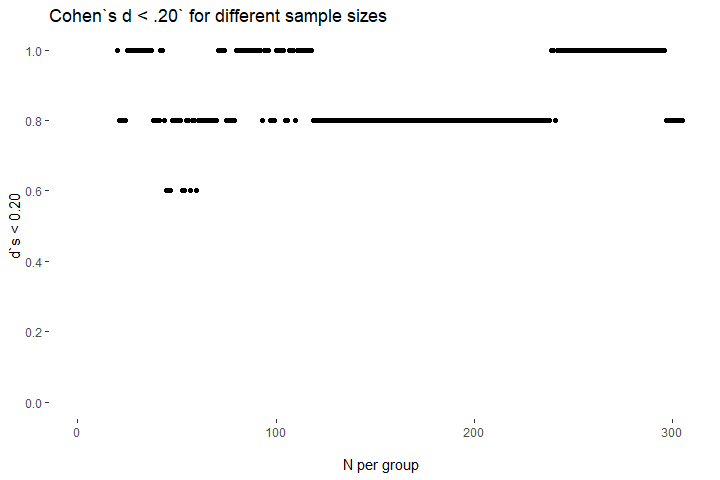

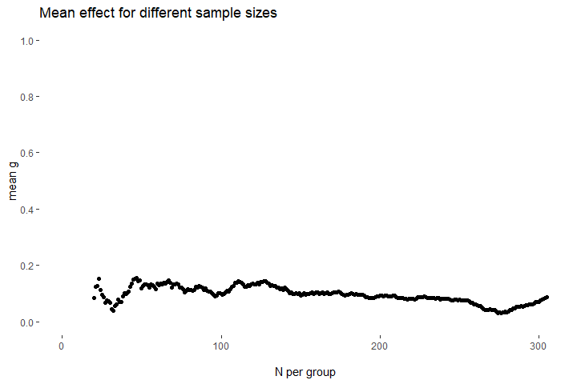

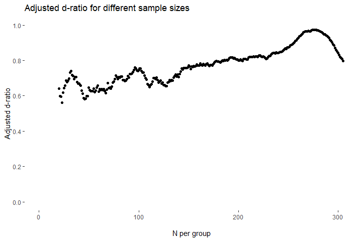

```r
# Plotting balance trend over sample size
Plot_MAGMA(Balance = Balance_gifted,
           criterion = c("Pillai", "d_ratio", "mean_g", "Adj_d_ratio"))
```

```r
Table_MAGMA(Balance = Balance_gifted,
            filename = "Balance_gifted.docx")
```

```
#> Balance table successfully created!
#> # A tibble: 4 × 6
#>   Criterion_optimized Pillai_Trace d_ratio mean_g adjusted_d_ratio n_per_group
#>   <chr>                      <dbl>   <dbl>  <dbl>            <dbl>       <int>
#> 1 Best Pillai                 0          1   0.03             0.97         276
#> 2 Best mean g                 0          1   0.03             0.97         276
#> 3 Best adj. d-ratio           0          1   0.03             0.97         276
#> 4 Best d-ratio                0.01       1   0.06             0.88         296
```

### Post-Matching Statistics

After the decision for a final matching model, we suggest reporting the descriptive statistics and pairwise effects of the selected model. To do this, we can use the same function as we used for reporting pre-matching statistics (`MAGMA_desc`). Additional to the parameters we specified above (`Data`, `covariates`, and `group`), we need to name the step variable (`step_var`) and the desired sample size per group (`step_num`). As above, this function results in a table with descriptive statistics and pairwise effects (Cohen’s d) of all covariates.

```r
# Computing descriptive statistics and pairwise effects for 100 cases per group
descs_gifted_post <- MAGMA_desc(Data = MAGMA_sim_data_gifted,
                                group = "gifted_support",
                                covariates = covariates_gifted,
                                step_num = 100,
                                step_var = "step",
                                filename = "stats_gifted_post.docx")

# Displaying the table with defined colum names
descs_gifted_post %>%
  purrr::set_names(c("Overall N", "Overall Mean", "Overall SD",
                     "No Support N", "No Support Mean", "No Support SD",
                     "Support N", "Support Mean", "Support SD",
                     "d"))
```

```
#>                  Overall N Overall Mean Overall SD No Support N No Support Mean
#> gifted_support         200         0.50       0.50          100            0.00
#> GPA_school             200         3.38       0.76          100            3.41
#> IQ_score               200       102.82      12.50          100          104.05
#> Motivation             200         3.87       0.84          100            3.87
#> parents_academic       200         0.42       0.49          100            0.39
#> gender                 200         0.47       0.50          100            0.49
#>                  No Support SD Support N Support Mean Support SD     d
#> gifted_support            0.00       100         1.00       0.00  -Inf
#> GPA_school                0.76       100         3.36       0.77  0.07
#> IQ_score                 12.13       100       101.59      12.80  0.20
#> Motivation                0.84       100         3.88       0.84 -0.01
#> parents_academic          0.49       100         0.45       0.50 -0.12
#> gender                    0.50       100         0.44       0.50  0.10
```

## Exact Matching

Unlike in standard matching, only cases sharing the same value on a variable can be matched in exact matching. In this example, the variable for exact matching is `enrichment`. This means that cases that participated in afternoon enrichment can only be matched with other cases that participated. Consequentially, non-participants can only be matched with other non-participants. Reasons for choosing exact matching instead of standard matching may be, for instance, a nested data structure. For example, students may come from different schools and only students from the same school should be matched together. Except for this preselection of possible matches, the process of matching stays the same as in the previous example. The main difference is that we need to use the function `MAGMA_exact` instead of `MAGMA` to match the data. This function has an additional argument, where the name of the exact variable must be defined as a character (`"enrichment"`). Note that the initial unbalance, descriptive statistics, and density overlap are the same as for standard matching.

```r
MAGMA_sim_data_gifted_exact <- MAGMA_exact(Data = MAGMA_sim_data,
                                           group = "gifted_support",
                                           dist = "ps_gifted",
                                           exact = "enrichment",
                                           cores = 2)
```

```
#>
#>  Input correctly identified!
#>  Distance computation finished. Starting matching
#>  Matching complete!
```

```r
str(MAGMA_sim_data_gifted_exact)
```

```
#> 'data.frame':    800 obs. of  17 variables:
#>  $ ID                    : int  1 2 3 4 5 6 7 8 9 10 ...
#>  $ gender                : int  1 0 1 1 1 0 0 0 1 0 ...
#>  $ gifted_support        : int  1 1 1 1 1 1 0 1 0 1 ...
#>  $ teacher_ability_rating: int  3 2 2 1 3 3 2 2 1 1 ...
#>  $ enrichment            : int  0 1 0 1 0 0 0 0 0 1 ...
#>  $ parents_academic      : int  1 1 1 0 1 0 0 1 0 0 ...
#>  $ GPA_school            : num  4.73 4.41 3.23 2.88 2.98 ...
#>  $ IQ_score              : num  111.6 97.8 120.1 97.9 74.4 ...
#>  $ Motivation            : num  5.36 4.41 3.57 4.34 3.54 ...
#>  $ college_GPA           : num  4.01 3.41 2.73 4.02 4.09 ...
#>  $ support_enrichment    : int  3 4 3 4 3 3 1 3 1 4 ...
#>  $ ps_tar                : num  0.0657 0.1085 0.1899 0.4261 0.4782 ...
#>  $ ps_2x2                : num  0.3 0.32 0.21 0.237 0.571 ...
#>  $ ps_gifted             : num  0.431 0.364 0.626 0.353 0.187 ...
#>  $ step                  : num  156 136 125 167 32 230 265 303 NA 18 ...
#>  $ weight                : num  1 1 1 1 1 1 1 1 NA 1 ...
#>  $ distance              : num  3.92e-05 1.91e-05 1.10e-05 9.41e-05 3.27e-08 ...
```